Name - Janhavee Kanoje

GH Number - GH1033705

Subject Code - M508A (Big Data Analytics)

Professor's Name - Narjes Nikzad

**Introduction**

Business Problem - Fake and misleading news against any organization can cause business risks and reputation can get jepardize. Analyzing this data can help organizations to gain automated valuable insights to identify and filter the fake news before letting it affect the organization.

Data source for this model is: https://www.kaggle.com/datasets/clmentbisaillon/fake-and-real-news-dataset

This task can be formulated as NLP task. Problem Statement - Develop a NLP pipeline that can identify fake and real news.

**Import Required Packages**

```python
!pip install kagglehub
!pip install gensim
!pip install transformers
!pip install tensorflow
import kagglehub
import numpy as np
import pandas as pd
import seaborn as sns
import matplotlib.pyplot as plt
import re, string
import nltk
import scipy.sparse
import torch

from kagglehub import KaggleDatasetAdapter

nltk.download('stopwords')
nltk.download('punkt')
nltk.download('punkt_tab')
nltk.download('wordnet')
from nltk import word_tokenize
from wordcloud import WordCloud
from nltk.corpus import stopwords
from nltk.stem import WordNetLemmatizer

from gensim.models import Word2Vec
from sklearn.model_selection import train_test_split
from sklearn.feature_extraction.text import TfidfVectorizer
from sklearn.linear_model import LogisticRegression
from sklearn.metrics import classification_report, accuracy_score, f1_score
from sklearn.ensemble import RandomForestClassifier
from sklearn.svm import SVC

from sklearn.utils.class_weight import compute_class_weight
import warnings
warnings.filterwarnings("ignore")
from datasets import Dataset
from transformers import BertTokenizer, BertForSequenceClassification
from transformers import TrainingArguments, Trainer
from torch.utils.data import TensorDataset, DataLoader, random_split
from transformers import Trainer, TrainingArguments
from keras.optimizers import Adam
from tensorflow.keras.preprocessing.text import Tokenizer
from tensorflow.keras.preprocessing.sequence import pad_sequences
from tensorflow.keras.models import Sequential
from tensorflow.keras.layers import Embedding, SimpleRNN, Dense, Dropout, LSTM, GlobalAveragePooling1D
from tensorflow.keras.callbacks import EarlyStopping, ReduceLROnPlateau
```

### **Load Data**

Load the two datasets "Fake" and "Real" news datasets, determine shapes and combine them, allocating labels : "0" = fake and "1" = true.

```python
true_df = kagglehub.load_dataset(
    KaggleDatasetAdapter.PANDAS,
    "clmentbisaillon/fake-and-real-news-dataset",
    "True.csv",
)
print(true_df.shape)

fake_df = kagglehub.load_dataset(
    KaggleDatasetAdapter.PANDAS,
    "clmentbisaillon/fake-and-real-news-dataset",
    "Fake.csv",
)
print(fake_df.shape)
```

```
(21417, 4)
(23481, 4)
```

```python
df_true = true_df.copy()
df_true['label'] = 1
df_fake = fake_df.copy()
df_fake['label'] = 0

df_news = pd.concat([df_true, df_fake], axis=0).reset_index(drop=True)
print(df_news.shape)
```

```
(44898, 5)
```

### **Data Exploration**

Check for null values, duplicate values, data types etc. As we can see there are duplicates present initially in the dataset, by using "drop_duplicates", the duplicates are removed.

```python
print(df_news['label'].value_counts())
```

```
label
0    23481
1    21417
Name: count, dtype: int64
```

```python
df_news.isnull().values.any()
```

```
False
```

```python
df_news.duplicated().sum()
```

```
209
```

```python
df_news.drop_duplicates(inplace=True)
```

```python
df_news.duplicated().sum()
```

```
0
```

```python
print(df_news.info())
```

[output not shown]

### **Data Preprocessing**

Create word cloud to identify different patterns, word frequency, etc in fake and real news.

I have tried to show a comparison between real and fake news via visualization.

```python
t_text = " ".join(df_true['text'])
f_text = " ".join(df_fake['text'])
```

```python
def create_enhanced_news_wordclouds(t_text, f_text):

    t_colors = ['#2E8B57', '#228B22', '#32CD32', '#006400']
    f_colors = ['#DC143C', '#B22222', '#FF6347', '#CD5C5C']

    t_wc = WordCloud(
        width=800,
        height=400,
        background_color='white',
        max_words=100,
        colormap='Greens',
        relative_scaling=0.5,
        min_font_size=10
    ).generate(t_text)

    f_wc = WordCloud(
        width=800,
        height=400,
        background_color='white',
        max_words=100,
        colormap='Reds',
        relative_scaling=0.5,
        min_font_size=10
    ).generate(f_text)
    plt.figure(figsize=(16, 8))


    plt.subplot(1, 2, 1)
    plt.imshow(t_wc, interpolation='bilinear')
    plt.axis('off')
    plt.title('True News Word Cloud', fontsize=16, fontweight='bold', color='green')

    plt.subplot(1, 2, 2)
    plt.imshow(f_wc, interpolation='bilinear')
    plt.axis('off')
    plt.title('Fake News Word Cloud', fontsize=16, fontweight='bold', color='red')

    plt.tight_layout()
    plt.show()
```

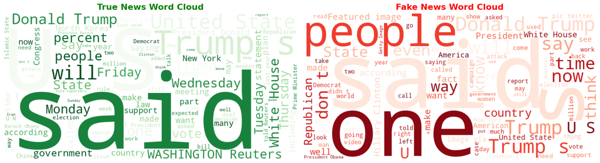

```python
create_enhanced_news_wordclouds(t_text, f_text)
```

#### Prepare text data for the models by cleaning and normalizing data.

For cleaning, tokenize text and split it into individual words, convert text to lowercase, remove punctuations, replace numbers by spaces, remove stopwords and lemmatize the text.

For normalization, convert multiple spaces to single spaces.

```python
tf_lemmatizer = WordNetLemmatizer()
tf_stopwords = set(stopwords.words('english'))

def Clean(text):
    text = str(text).lower()
    text = re.sub(f"[{string.punctuation}]", "", text)
    text = re.sub(r'\d+', ' ', text)
    text = re.sub(r'\s+', ' ', text).strip()
    tokens = word_tokenize(text)
    tokens = [tf_lemmatizer.lemmatize(w) for w in tokens if w not in tf_stopwords]
    return " ".join(tokens)

df_news['clean_text'] = df_news['text'].apply(Clean)
print(df_news[['clean_text', 'label']].head())
```

[output not shown]

### **Feature Engineering**

Split the cleaned data into train and test sets, for all the models usage.

```python
X_tf_train, X_tf_test, y_tf_train, y_tf_test = train_test_split(df_news['clean_text'], df_news['label'], test_size=0.2, random_state=42)
```

### **TF-IDF Model**

Avoid baises dues to imbalanced dataset.

Balancing dataset can help acheive a fair result without being baised towards the majority class.

```python
weights_lr = compute_class_weight(
    class_weight='balanced',
    classes=np.unique(y_tf_train),
    y=y_tf_train
)
weights_lr_dict = {i: weight for i, weight in enumerate(weights_lr)}
print(f"Class weights for Logistic Regression: {weights_lr_dict}")
```

```
Class weights for Logistic Regression: {0: 0.9493096123207647, 1: 1.0564091956740145}
```

Covert text data into numerical data based on the text frequncy for the model to process.

```python
vectorizer = TfidfVectorizer(
    max_features=5000,
    ngram_range=(1, 2),
    min_df=2,
    max_df=0.98,
)

X_tfidf_train = vectorizer.fit_transform(X_tf_train)
X_tfidf_test = vectorizer.transform(X_tf_test)
print(X_tfidf_train.shape, X_tfidf_test.shape)
```

```
(35751, 5000) (8938, 5000)
```

Train TF-IDF model

```python
lr_model = LogisticRegression(
    class_weight=weights_lr_dict,
    solver='liblinear',
    max_iter=1000,
    random_state=42)

lr_model.fit(X_tfidf_train, y_tf_train)
y_lr_predict = lr_model.predict(X_tfidf_test)

print(classification_report(y_tf_test, y_lr_predict))
```

[output not shown]

### **Word2Vec**

Prepare text by tokenizing text into tokens, convert text tokens into sequence of integers based on semantic similarity.

```python
sentences = [word_tokenize(text) for text in df_news['clean_text']]
w2v_model = Word2Vec(sentences, vector_size=100, window=5, min_count=2)
```

```python
tokenizer_w2v = Tokenizer()
tokenizer_w2v.fit_on_texts(df_news['clean_text'])
sequences_w2v = tokenizer_w2v.texts_to_sequences(df_news['clean_text'])
X_tf_pad = pad_sequences(sequences_w2v, maxlen=100)
```

```python
embedding_matrix = np.zeros((len(tokenizer_w2v.word_index)+1, 100))
for word, i in tokenizer_w2v.word_index.items():
    if word in w2v_model.wv:
        embedding_matrix[i] = w2v_model.wv[word]
```

Split the data into train and test sets using padded, sequnced data.

```python
X_train, X_test, y_train, y_test = train_test_split(X_tf_pad, df_news['label'], test_size=0.2, random_state=42)
```

```python
class_weights_w2v = compute_class_weight(
    class_weight='balanced',
    classes=np.unique(y_train),
    y=y_train
)
class_weight_w2v_dict = {i: weight for i, weight in enumerate(class_weights_w2v)}
print(f"Class weights for Logistic Regression: {class_weight_w2v_dict}")
```

[output not shown]

#### ANN Model

Initialize Callback functions : earlystoping to save time and improve computational efficiency and learning rate to prevent overfitting and improve convergence.

```python
es = EarlyStopping(monitor='val_loss', patience=5, restore_best_weights=True)
lr = ReduceLROnPlateau(monitor='val_loss', factor=0.5, patience=3, min_lr=1e-6)
```

Train the ANN model

```python
model = Sequential([
        Embedding(len(tokenizer_w2v.word_index)+1, 100, weights=[embedding_matrix],trainable=False),
        GlobalAveragePooling1D(),
        Dense(128, activation='relu'),
        Dropout(0.5),
        Dense(64, activation='relu'),
        Dropout(0.3),
        Dense(32, activation='relu'),
        Dropout(0.2),
        Dense(1, activation='sigmoid')
    ])

model.compile(optimizer=Adam(learning_rate=0.001),loss='binary_crossentropy',metrics=['accuracy', 'precision', 'recall'])
history = model.fit(X_train, y_train, epochs=30, validation_split=0.1, class_weight= class_weight_w2v_dict, callbacks=[es,lr], verbose=1)
print(f"Test Accuracy: {model.evaluate(X_test, y_test)[1]*100:.2f}%")
```

Test Accuracy : 97.08%

RNN

Initialize callback functions

```python
es = EarlyStopping(monitor='val_loss', patience=5, restore_best_weights=True)
lr = ReduceLROnPlateau(monitor='val_loss', factor=0.5, patience=3, min_lr=1e-6)
```

Train RNN model

```python
model_rnn = Sequential([
    Embedding(len(tokenizer_w2v.word_index)+1, 100, weights=[embedding_matrix], trainable=False),
    SimpleRNN(64, dropout=0.3, recurrent_dropout=0.3),
        Dense(64, activation='relu'),
        Dropout(0.5),
        Dense(32, activation='relu'),
        Dropout(0.3),
        Dense(1, activation='sigmoid')
])
model_rnn.compile(optimizer='adam', loss='binary_crossentropy', metrics=['accuracy', 'precision', 'recall'])
history_rnn = model_rnn.fit(X_train, y_train, epochs=40, validation_split=0.1, class_weight= weights_lr_dict, callbacks=[es,lr], verbose=1)
print(f"Test Accuracy: {model_rnn.evaluate(X_test, y_test)[1]*100:.2f}%")
```

Test Accuracy : 94.70%

### **BERT**

Convert the text column into list of strings and target labels into list.

Split the converted data into train and test sets.

```python
texts = list(df_news['text'].astype(str))
labels = list(df_news['label'])
```

```python
X_train_bert, X_test_bert, y_train_bert, y_test_bert = train_test_split(
    texts, labels, test_size=0.2, random_state=42, stratify=df_news['label']
)

print(f"Training set: {len(X_train_bert)} samples")
print(f"Test set: {len(X_test_bert)} samples")
```

[output not shown]

Build BERT model

Load bert's uncased pretrained model and set-up.

Perform data encoding and create input_ids and attention_mask.

Use dataset.from_dict() to create huggingface datasets.

```python
model_name = "bert-base-uncased"
tokenizer = BertTokenizer.from_pretrained(model_name)
Bert_model = BertForSequenceClassification.from_pretrained(model_name, num_labels=2)
```

```
Some weights of BertForSequenceClassification were not initialized from the model checkpoint at bert-base-uncased and are newly initialized: ['classifier.bias', 'classifier.weight']
You should probably TRAIN this model on a down-stream task to be able to use it for predictions and inference.
```

```python
train_encodings = tokenizer(
    X_train_bert, truncation=True, padding=True, max_length=128, return_tensors="pt"
)
val_encodings = tokenizer(
   X_test_bert, truncation=True, padding=True, max_length=128, return_tensors="pt"
)
```

```python
train_bert_dataset = Dataset.from_dict({
    'input_ids': train_encodings['input_ids'],
    'attention_mask': train_encodings['attention_mask'],
    'labels': y_train_bert
})

test_bert_dataset = Dataset.from_dict({
    'input_ids': val_encodings['input_ids'],
    'attention_mask': val_encodings['attention_mask'],
    'labels': y_test_bert
})
```

Define computing matrics to analyze the results.

```python
def compute(eval_pred):
    preds, labels = eval_pred
    preds = np.argmax(preds, axis=1)
    return {
        "accuracy": accuracy_score(labels, preds),
        "f1": f1_score(labels, preds, zero_division=0),
    }
```

Tune the Bert model by tuning the hyper parameters.

```python
Bert_arguments_queue = TrainingArguments(
    output_dir="./results",
    num_train_epochs=1,
    per_device_train_batch_size=16,
    per_device_eval_batch_size=16,
    eval_strategy="epoch",
    save_strategy="epoch",
    logging_steps=50,
)
```

Train the model using huggingface training interface

```python
trainer = Trainer(
    model=Bert_model,
    args=Bert_arguments_queue,
    train_dataset=train_bert_dataset,
    eval_dataset=test_bert_dataset,
    tokenizer=tokenizer,
    compute_metrics=compute
)

print("Training...")
trainer.train()
print("Training completed!")
```

[output not shown]

#### Result Evaluation

W2V + ANN = 0.97 accuracy; W2V + RNN = 0.94

ANN model was quick as compared to RNN model as it took more number of epochs.

BERT model on the other hand exhausts lot of computational power and time due to GPU usage.

The results for this dataset on different models are quite contrasting to what usually happens. TF-IDF is the simplest amongst the all and usually shows lower performance but for this smaller dataset it proved to be more efficient and accurate.

### **Conclusion**

This detection pipeline might help organization to pin point the misleading news, by classifying them through this method.

Organization can fight against the fake news and protect their market reputation and business.

There are certain loopholes to this models, more fine tunning might change the best model decesion and might give another more accurate model. But this methodology might establish a robust technical and automated solution against spreading fake news.

This Model can hereby be deployed, and used by the organization to avoid business risks.